# 5. Diabetes Absolute Number with Tax Delta

### Importing necessary libraries

```python
import pandas as pd
import numpy as np
import seaborn as sns
import matplotlib.pyplot as plt
import statsmodels.api as sm

# code to ignore warnings
import warnings
warnings.filterwarnings("ignore")

root_csv = '../csv files/'
root_pickle = '../pickle files/'
```

### Reading files

```python
df_diab_total_pivot = pd.read_pickle(root_pickle +'Diabetes_Total_Pivot.pkl')
df_diab_gender_pivot = pd.read_pickle(root_pickle +'Diabetes_Gender_Pivot.pkl')
df_diab_age_pivot = pd.read_pickle(root_pickle +'Diabetes_Age_Pivot.pkl')
```

### Reviewing data

```python
df_diab_total_pivot.head(5)
```

|  | State | County | CountyFIPS | Year | Total Absolute | Total Percentage | Grocery Tax | Restaurant Tax | tax_delta | Population |
| --- | --- | --- | --- | --- | --- | --- | --- | --- | --- | --- |
| 0 | Alabama | Autauga County | 1001 | 2004 | 2470.0 | 7.5 | 0.04 | 0.04 | 0.0 | 32933.333333 |
| 6 | Alabama | Autauga County | 1001 | 2005 | 3010.0 | 8.9 | 0.04 | 0.04 | 0.0 | 33820.226169 |
| 12 | Alabama | Autauga County | 1001 | 2006 | 3482.0 | 10.0 | 0.04 | 0.04 | 0.0 | 34820.000000 |
| 18 | Alabama | Autauga County | 1001 | 2007 | 3332.0 | 9.4 | 0.04 | 0.04 | 0.0 | 35446.809949 |
| 24 | Alabama | Autauga County | 1001 | 2008 | 3563.0 | 9.9 | 0.04 | 0.04 | 0.0 | 35989.900377 |

```python
df_diab_gender_pivot.head(5)
```

|  | State | County | CountyFIPS | Year | Gender Absolute | Gender Percentage | Gender | Grocery Tax | Restaurant Tax | tax_delta | Population |
| --- | --- | --- | --- | --- | --- | --- | --- | --- | --- | --- | --- |
| 0 | Alabama | Autauga County | 1001 | 2004 | 1281.0 | 7.4 | Female | 0.04 | 0.04 | 0.0 | 17310.810588 |
| 3 | Alabama | Autauga County | 1001 | 2004 | 1189.0 | 7.6 | Male | 0.04 | 0.04 | 0.0 | 15644.737038 |
| 6 | Alabama | Autauga County | 1001 | 2005 | 1523.0 | 8.6 | Female | 0.04 | 0.04 | 0.0 | 17709.301540 |
| 9 | Alabama | Autauga County | 1001 | 2005 | 1487.0 | 9.3 | Male | 0.04 | 0.04 | 0.0 | 15989.246984 |
| 12 | Alabama | Autauga County | 1001 | 2006 | 1758.0 | 9.7 | Female | 0.04 | 0.04 | 0.0 | 18123.711697 |

```python
df_diab_age_pivot.head(5)
```

|  | State | County | CountyFIPS | Year | Age Diabetics Absolute | Age Diabetics Percentage | Age | Grocery Tax | Restaurant Tax | tax_delta | Population |
| --- | --- | --- | --- | --- | --- | --- | --- | --- | --- | --- | --- |
| 0 | Alabama | Autauga County | 1001 | 2004 | 472.0 | 2.900000 | 20-44 | 0.04 | 0.04 | 0.0 | 16275.861534 |
| 1 | Alabama | Autauga County | 1001 | 2004 | 1179.0 | 10.300000 | 45-64 | 0.04 | 0.04 | 0.0 | 11446.601730 |
| 2 | Alabama | Autauga County | 1001 | 2004 | 819.0 | 16.299999 | 65-beyond | 0.04 | 0.04 | 0.0 | 5024.540112 |
| 6 | Alabama | Autauga County | 1001 | 2005 | 582.0 | 3.500000 | 20-44 | 0.04 | 0.04 | 0.0 | 16628.571429 |
| 7 | Alabama | Autauga County | 1001 | 2005 | 1458.0 | 12.300000 | 45-64 | 0.04 | 0.04 | 0.0 | 11853.658353 |

### Regression Analysis at County level data

#### 1. Baseline without controls

##### a. With Total Absolute as Response Variable:

##### Note:

Even though Total Absolute does not make sense as concluded from EDA, we are carrying regression on it.

```python
import numpy as np
import pandas as pd
import statsmodels.api as sm
from sklearn.model_selection import train_test_split
from sklearn.linear_model import LinearRegression
from sklearn.metrics import mean_squared_error, r2_score

# Assuming 'Grocery Tax' and 'Restaurant Tax' are the features
X = df_diab_total_pivot['tax_delta']
y = df_diab_total_pivot['Total Absolute']

# Add a constant term to the features matrix (required for statsmodels)
X = sm.add_constant(X)

# Create and fit the linear regression model using statsmodels
stats_model = sm.OLS(y, X).fit()

# Print the summary
print(stats_model.summary())
```

```
                            OLS Regression Results
==============================================================================
Dep. Variable:         Total Absolute   R-squared:                       0.016
Model:                            OLS   Adj. R-squared:                  0.016
Method:                 Least Squares   F-statistic:                     847.4
Date:                Sat, 25 Nov 2023   Prob (F-statistic):          7.68e-185
Time:                        16:28:42   Log-Likelihood:            -6.0438e+05
No. Observations:               53318   AIC:                         1.209e+06
Df Residuals:                   53316   BIC:                         1.209e+06
Df Model:                           1
Covariance Type:            nonrobust
==============================================================================
                 coef    std err          t      P>|t|      [0.025      0.975]
------------------------------------------------------------------------------
const       2511.7852    165.012     15.222      0.000    2188.361    2835.209
tax_delta    1.02e+05   3505.205     29.109      0.000    9.52e+04    1.09e+05
==============================================================================
Omnibus:                    99184.667   Durbin-Watson:                   0.110
Prob(Omnibus):                  0.000   Jarque-Bera (JB):        255763530.854
Skew:                          13.942   Prob(JB):                         0.00
Kurtosis:                     341.156   Cond. No.                         40.0
==============================================================================

Notes:
[1] Standard Errors assume that the covariance matrix of the errors is correctly specified.
```

##### Conclusion:

The baseline model with response as total number of diabetics and predictor variables grocery tax and restaurant tax:

- One percent increase in tax delta, keeping all other constant, increases the absolute number by 1.02 x 10^5
- p-value is close to 0 in both cases. Hence the coefficients of regression are statistically significant
- Adjusted R-square is 0.016 indicating that the model can explain only 1.6% of variation in total number of diabetics patient
- Again, this model was fitted only on absolute numbers and we will switch to a more better approach of percentages.

#### 2. With single controls

##### a. Gender Control - On Absolute Number

```python
import numpy as np
import pandas as pd
import statsmodels.api as sm
from sklearn.model_selection import train_test_split
from sklearn.linear_model import LinearRegression
from sklearn.metrics import mean_squared_error, r2_score

# One Hot Encoding Gender in predictor variable
X = pd.get_dummies(df_diab_gender_pivot[['tax_delta', 'Gender']], columns=['Gender'], drop_first=True)
y = df_diab_gender_pivot['Gender Absolute']

# Add a constant term to the features matrix (required for statsmodels)
X = sm.add_constant(X)

# Create and fit the linear regression model using statsmodels
stats_model = sm.OLS(y, X).fit()

# Print the summary
print(stats_model.summary())
```

```
                            OLS Regression Results
==============================================================================
Dep. Variable:        Gender Absolute   R-squared:                       0.016
Model:                            OLS   Adj. R-squared:                  0.016
Method:                 Least Squares   F-statistic:                     845.7
Date:                Sat, 25 Nov 2023   Prob (F-statistic):               0.00
Time:                        16:28:42   Log-Likelihood:            -1.1349e+06
No. Observations:              106631   AIC:                         2.270e+06
Df Residuals:                  106628   BIC:                         2.270e+06
Df Model:                           2
Covariance Type:            nonrobust
===============================================================================
                  coef    std err          t      P>|t|      [0.025      0.975]
-------------------------------------------------------------------------------
const        1256.8309     66.147     19.001      0.000    1127.184    1386.477
tax_delta    5.102e+04   1240.627     41.126      0.000    4.86e+04    5.35e+04
Gender_Male    -1.8510     62.109     -0.030      0.976    -123.584     119.882
==============================================================================
Omnibus:                   198295.631   Durbin-Watson:                   0.065
Prob(Omnibus):                  0.000   Jarque-Bera (JB):        510829407.562
Skew:                          13.946   Prob(JB):                         0.00
Kurtosis:                     340.931   Cond. No.                         45.8
==============================================================================

Notes:
[1] Standard Errors assume that the covariance matrix of the errors is correctly specified.
```

##### Conclusion:

The model with response as total number of diabetics and predictor variables grocery tax and restaurant tax and control on gender:

- One percent increase in tax delta, keeping all other constant, increases the absolute number by 5.102 x 10^4
- If the gender is male, keeping all other constant, the absolute number decreases by 1.851.
- p-value of gender male is >0.05. Hence the coefficients of regression of gender is not statistically significant
- Adjusted R-square is 0.016 indicating that the model can explain only 1.6% of variation in total number of diabetics patient
- Again, this model was fitted on absolute numbers and we will switch to a more better approach of percentages.

##### b. Age Control - On Absolute Number

```python
import numpy as np
import pandas as pd
import statsmodels.api as sm
from sklearn.model_selection import train_test_split
from sklearn.linear_model import LinearRegression
from sklearn.metrics import mean_squared_error, r2_score

# One Hot Encoding Gender in predictor variable
X = pd.get_dummies(df_diab_age_pivot[['tax_delta', 'Age']], columns=['Age'], drop_first=True)
y = df_diab_age_pivot['Age Diabetics Absolute']

# Add a constant term to the features matrix (required for statsmodels)
X = sm.add_constant(X)

# Create and fit the linear regression model using statsmodels
stats_model = sm.OLS(y, X).fit()

# Print the summary
print(stats_model.summary())
```

```
                              OLS Regression Results
==================================================================================
Dep. Variable:     Age Diabetics Absolute   R-squared:                       0.027
Model:                                OLS   Adj. R-squared:                  0.027
Method:                     Least Squares   F-statistic:                     1447.
Date:                    Sat, 25 Nov 2023   Prob (F-statistic):               0.00
Time:                            16:28:42   Log-Likelihood:            -1.6365e+06
No. Observations:                  158645   AIC:                         3.273e+06
Df Residuals:                      158641   BIC:                         3.273e+06
Df Model:                               3
Covariance Type:                nonrobust
=================================================================================
                    coef    std err          t      P>|t|      [0.025      0.975]
---------------------------------------------------------------------------------
const          -353.1761     43.459     -8.127      0.000    -438.355    -267.997
tax_delta      3.428e+04    733.775     46.712      0.000    3.28e+04    3.57e+04
Age_45-64      1998.7542     45.036     44.381      0.000    1910.485    2087.024
Age_65-beyond  1561.5151     45.038     34.671      0.000    1473.241    1649.789
==============================================================================
Omnibus:                   316978.250   Durbin-Watson:                   0.439
Prob(Omnibus):                  0.000   Jarque-Bera (JB):       1533951501.358
Skew:                          16.178   Prob(JB):                         0.00
Kurtosis:                     483.636   Cond. No.                         44.7
==============================================================================

Notes:
[1] Standard Errors assume that the covariance matrix of the errors is correctly specified.
```

##### Conclusion:

The model with response as total number of diabetics and predictor variables grocery tax and restaurant tax and control on age:

- One percent increase in tax delta, keeping all other constant, increases the absolute number by 3.428 x 10^4
- If the age is between 45-64, keeping all other constant, the absolute number increases by 1998.
- If the age is between 65-beyond, keeping all other constant, the absolute number increases by 1561.
- All p values are statistically significant
- Adjusted R-square is 0.027 indicating that the model can explain only 2.7% of variation in total number of diabetics patient
- Again, this model was fitted on absolute numbers and we will switch to a more better approach of percentages.

##### c. Total Population - On Absolute Number

```python
import numpy as np
import pandas as pd
import statsmodels.api as sm
from sklearn.model_selection import train_test_split
from sklearn.linear_model import LinearRegression
from sklearn.metrics import mean_squared_error, r2_score

# Assuming 'Grocery Tax' and 'Restaurant Tax' are the features
X = df_diab_total_pivot[['tax_delta','Population']]
y = df_diab_total_pivot['Total Absolute']

# Add a constant term to the features matrix (required for statsmodels)
X = sm.add_constant(X)

# Create and fit the linear regression model using statsmodels
stats_model = sm.OLS(y, X).fit()

# Print the summary
print(stats_model.summary())
```

```
                            OLS Regression Results
==============================================================================
Dep. Variable:         Total Absolute   R-squared:                       0.968
Model:                            OLS   Adj. R-squared:                  0.968
Method:                 Least Squares   F-statistic:                 8.012e+05
Date:                Sat, 25 Nov 2023   Prob (F-statistic):               0.00
Time:                        16:28:43   Log-Likelihood:            -5.1320e+05
No. Observations:               53318   AIC:                         1.026e+06
Df Residuals:                   53315   BIC:                         1.026e+06
Df Model:                           2
Covariance Type:            nonrobust
==============================================================================
                 coef    std err          t      P>|t|      [0.025      0.975]
------------------------------------------------------------------------------
const        274.6558     29.898      9.186      0.000     216.056     333.256
tax_delta    916.9746    639.060      1.435      0.151    -335.588    2169.538
Population     0.0855   6.81e-05   1255.610      0.000       0.085       0.086
==============================================================================
Omnibus:                    68434.183   Durbin-Watson:                   0.379
Prob(Omnibus):                  0.000   Jarque-Bera (JB):        422353427.379
Skew:                          -5.896   Prob(JB):                         0.00
Kurtosis:                     438.861   Cond. No.                     9.92e+06
==============================================================================

Notes:
[1] Standard Errors assume that the covariance matrix of the errors is correctly specified.
[2] The condition number is large, 9.92e+06. This might indicate that there are
strong multicollinearity or other numerical problems.
```

#### Conclusion:

The model with response as number of diabetics and predictor variable tax delta and population:

- One percent increase in tax delta, keeping all other constant, increases the diabetics number by 916.
- One unit increase in population, keeping all other constant, increases the diabetics number by 0.08.
- Grocery p-value is not statistically significant
- Adjusted R-square is 0.968 indicating that the model can explain only 96.8% of variation in total number of diabetics patient
- The conditional number is large and hence we need to check for multicollinearity
- This model has good R-square value but we need to validate the linearity assumptions and if any is violated, apply necessary trasformation

```python
# Checking for multicollinearity
from statsmodels.stats.outliers_influence import variance_inflation_factor

vif_data = pd.DataFrame()
vif_data["Variable"] = X.columns
vif_data["VIF"] = [variance_inflation_factor(X.values, i) for i in range(X.shape[1])]

# Check the VIF values
print(vif_data)
```

```
     Variable       VIF
0       const  3.549673
1   tax_delta  1.016137
2  Population  1.016137
```

##### Inference:

The VIF for predictor variables is small and hence multicollinearity does not exist. Scaling can fix the error if needed.

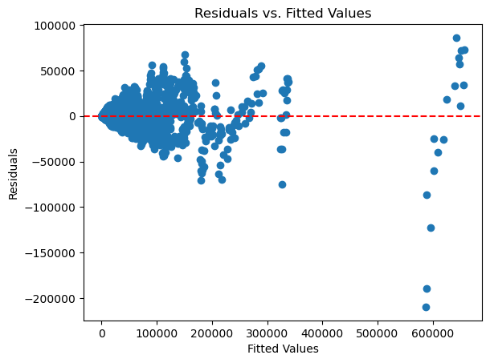

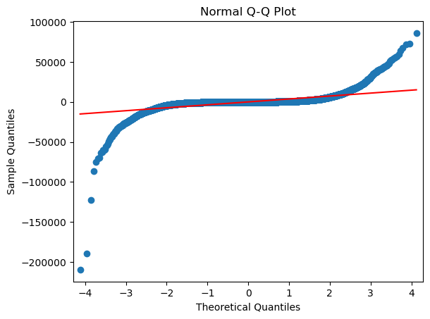

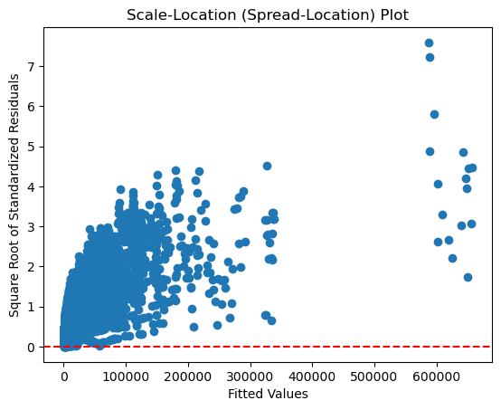

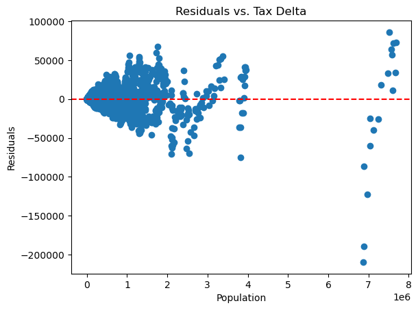

```python
# Validating for linearity assumptions

import statsmodels.api as sm
import matplotlib.pyplot as plt
import scipy.stats as stats
import numpy as np

# Assuming you have already fitted the linear regression model named 'model'

# Get fitted values and residuals
fitted_values = stats_model.fittedvalues
residuals = stats_model.resid

# 1. Residuals vs. Fitted Values Plot
plt.scatter(fitted_values, residuals)
plt.xlabel('Fitted Values')
plt.ylabel('Residuals')
plt.title('Residuals vs. Fitted Values')
plt.axhline(y=0, color='r', linestyle='--')  # Add a horizontal line at y=0
plt.show()

# 2. Normal Q-Q Plot
sm.qqplot(residuals, line='s')
plt.title('Normal Q-Q Plot')
plt.show()

# 3. Scale-Location (Spread-Location) Plot
sqrt_standardized_residuals = np.sqrt(np.abs(stats_model.get_influence().resid_studentized_internal))
plt.scatter(fitted_values, sqrt_standardized_residuals)
plt.xlabel('Fitted Values')
plt.ylabel('Square Root of Standardized Residuals')
plt.title('Scale-Location (Spread-Location) Plot')
plt.axhline(y=0, color='r', linestyle='--')  # Add a horizontal line at y=0
plt.show()

# 4. Residuals vs. Predictor Plot for ''
plt.scatter(df_diab_total_pivot['Population'], residuals)
plt.xlabel('Population')
plt.ylabel('Residuals')
plt.title('Residuals vs. Tax Delta')
plt.axhline(y=0, color='r', linestyle='--')  # Add a horizontal line at y=0
plt.show()
```

##### Inference:

Linearity assumptions are being violated. Lets apply Box-Cox transformations to fix that.

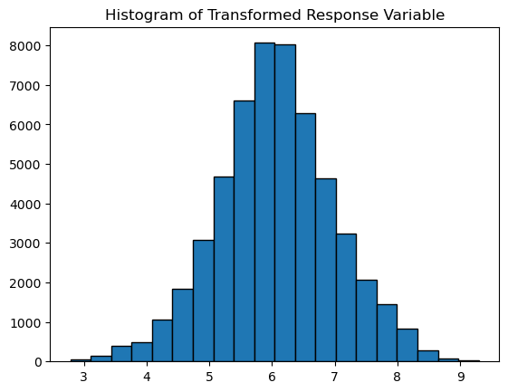

```
Lambda Value: -0.05917551974946644
                            OLS Regression Results
==============================================================================
Dep. Variable:                      y   R-squared:                       0.268
Model:                            OLS   Adj. R-squared:                  0.268
Method:                 Least Squares   F-statistic:                     9767.
Date:                Sat, 25 Nov 2023   Prob (F-statistic):               0.00
Time:                        16:28:45   Log-Likelihood:                -63429.
No. Observations:               53318   AIC:                         1.269e+05
Df Residuals:                   53315   BIC:                         1.269e+05
Df Model:                           2
Covariance Type:            nonrobust
==============================================================================
                 coef    std err          t      P>|t|      [0.025      0.975]
------------------------------------------------------------------------------
const          5.7398      0.006    884.737      0.000       5.727       5.753
tax_delta      4.6331      0.139     33.411      0.000       4.361       4.905
Population  1.927e-06   1.48e-08    130.422      0.000     1.9e-06    1.96e-06
==============================================================================
Omnibus:                    20843.470   Durbin-Watson:                   0.096
Prob(Omnibus):                  0.000   Jarque-Bera (JB):           328935.888
Skew:                          -1.459   Prob(JB):                         0.00
Kurtosis:                      14.813   Cond. No.                     9.92e+06
==============================================================================

Notes:
[1] Standard Errors assume that the covariance matrix of the errors is correctly specified.
[2] The condition number is large, 9.92e+06. This might indicate that there are
strong multicollinearity or other numerical problems.
```

```python
# Applying the Box-Cox transformation

# Apply Box-Cox Transformation to Response Variable
y_transformed, lambda_value = stats.boxcox(y + 1)  # Adding 1 to handle zero values

# Visualize the Transformed Response Variable
plt.hist(y_transformed, bins=20, edgecolor='black')
plt.title('Histogram of Transformed Response Variable')
plt.show()

# Check Lambda Value
print(f'Lambda Value: {lambda_value}')

# Fit a new model using the transformed response variable
stats_model_transformed = sm.OLS(y_transformed, X).fit()

# Print the summary of the transformed model
print(stats_model_transformed.summary())
```

##### Conclusion:

The model with response as number of diabetics and predictor variable tax delta and population:

- The lambda value is -0.05. Indicating the new model fit is on (((diabetics number^-0.059)-1)/-0.059). We will call this response as transformed y.
- One percent increase in tax delta, keeping all other constant, increases the transformed by 4.63
- One unit increase in population, keeping all other constant, increases the transformed y by 1.92 x 10^-6.
- All p-value are statistically significant
- Adjusted R-square is 0.268 indicating that the model can explain only 26.8% of variation in total number of diabetics patient
- To fix the conditional large number lets explore scaling.

```python
import statsmodels.api as sm
from sklearn.preprocessing import StandardScaler
import pandas as pd

df_diab_scaled = df_diab_total_pivot.reset_index(drop=True)
df_diab_scaled

# Extract the independent variables (features) from your DataFrame
X = df_diab_scaled[['tax_delta', 'Population']]

# Extract the dependent variable from your DataFrame
y = df_diab_scaled['Total Absolute']

# Initialize the StandardScaler
scaler = StandardScaler()

# Fit and transform the independent variables
X_scaled = scaler.fit_transform(X)

# Create a new DataFrame with the scaled features
X_scaled_df = pd.DataFrame(X_scaled, columns=X.columns)

# Add a constant term to the independent variables
X_scaled_df = sm.add_constant(X_scaled_df)

# Fit the linear regression model
model = sm.OLS(y, X_scaled_df).fit()

# Display the summary
print(model.summary())
```

```
                            OLS Regression Results
==============================================================================
Dep. Variable:         Total Absolute   R-squared:                       0.968
Model:                            OLS   Adj. R-squared:                  0.968
Method:                 Least Squares   F-statistic:                 8.012e+05
Date:                Sat, 25 Nov 2023   Prob (F-statistic):               0.00
Time:                        16:28:45   Log-Likelihood:            -5.1320e+05
No. Observations:               53318   AIC:                         1.026e+06
Df Residuals:                   53315   BIC:                         1.026e+06
Df Model:                           2
Covariance Type:            nonrobust
==============================================================================
                 coef    std err          t      P>|t|      [0.025      0.975]
------------------------------------------------------------------------------
const       6579.9008     15.869    414.643      0.000    6548.798    6611.004
tax_delta     22.9529     15.996      1.435      0.151      -8.400      54.306
Population  2.009e+04     15.996   1255.610      0.000    2.01e+04    2.01e+04
==============================================================================
Omnibus:                    68434.183   Durbin-Watson:                   0.379
Prob(Omnibus):                  0.000   Jarque-Bera (JB):        422353427.390
Skew:                          -5.896   Prob(JB):                         0.00
Kurtosis:                     438.861   Cond. No.                         1.14
==============================================================================

Notes:
[1] Standard Errors assume that the covariance matrix of the errors is correctly specified.
```

##### Since the above model violates linearity assumptions, applying Box-Cox transformation to scaled parameters

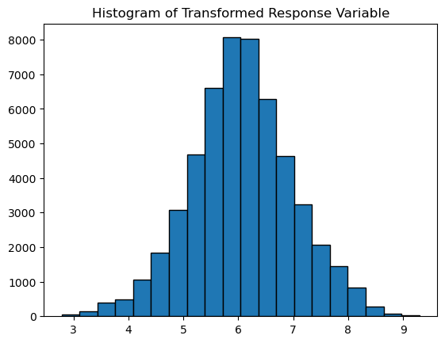

```
Lambda Value: -0.05917551974946644
                            OLS Regression Results
==============================================================================
Dep. Variable:                      y   R-squared:                       0.268
Model:                            OLS   Adj. R-squared:                  0.268
Method:                 Least Squares   F-statistic:                     9767.
Date:                Sat, 25 Nov 2023   Prob (F-statistic):               0.00
Time:                        16:28:46   Log-Likelihood:                -63429.
No. Observations:               53318   AIC:                         1.269e+05
Df Residuals:                   53315   BIC:                         1.269e+05
Df Model:                           2
Covariance Type:            nonrobust
==============================================================================
                 coef    std err          t      P>|t|      [0.025      0.975]
------------------------------------------------------------------------------
const          6.0658      0.003   1761.573      0.000       6.059       6.073
tax_delta      0.1160      0.003     33.411      0.000       0.109       0.123
Population     0.4527      0.003    130.422      0.000       0.446       0.460
==============================================================================
Omnibus:                    20843.470   Durbin-Watson:                   0.096
Prob(Omnibus):                  0.000   Jarque-Bera (JB):           328935.891
Skew:                          -1.459   Prob(JB):                         0.00
Kurtosis:                      14.813   Cond. No.                         1.14
==============================================================================

Notes:
[1] Standard Errors assume that the covariance matrix of the errors is correctly specified.
```

```python
# Applying the Box-Cox transformation

# Apply Box-Cox Transformation to Response Variable
y_transformed, lambda_value = stats.boxcox(y + 1)  # Adding 1 to handle zero values

# Visualize the Transformed Response Variable
plt.hist(y_transformed, bins=20, edgecolor='black')
plt.title('Histogram of Transformed Response Variable')
plt.show()

# Check Lambda Value
print(f'Lambda Value: {lambda_value}')

# Fit a new model using the transformed response variable
stats_model_transformed = sm.OLS(y_transformed, X_scaled_df).fit()

# Print the summary of the transformed model
print(stats_model_transformed.summary())
```

##### Conclusion:

The model with response as number of diabetics and predictor variable tax and population:

- The lambda value is -0.059. Indicating the new model fit is on (((diabetics number^-0.059)-1)/-0.059). We will call this response as transformed y.
- One percent increase in scaled tax delta, keeping all other constant, increases the transformed by 0.116.
- One unit increase in scaled population, keeping all other constant, increases the transformed y by 0.4527.
- All p-value are statistically significant
- Adjusted R-square is 0.268 indicating that the model can explain only 26.8% of variation in total number of diabetics patient
- Conditonal large number error has been fixed

#### 3. With multiple controls

##### a. Total Population and Gender - On Absolute Number

```python
import numpy as np
import pandas as pd
import statsmodels.api as sm
from sklearn.model_selection import train_test_split
from sklearn.linear_model import LinearRegression
from sklearn.metrics import mean_squared_error, r2_score

# Assuming 'Grocery Tax' and 'Restaurant Tax' are the features
X = pd.get_dummies(df_diab_gender_pivot[['tax_delta','Population', 'Gender']], columns=['Gender'], drop_first=True)
y = df_diab_gender_pivot['Gender Absolute']

# Add a constant term to the features matrix (required for statsmodels)
X = sm.add_constant(X)

# Create and fit the linear regression model using statsmodels
stats_model = sm.OLS(y, X).fit()

# Print the summary
print(stats_model.summary())
```

```
                            OLS Regression Results
==============================================================================
Dep. Variable:        Gender Absolute   R-squared:                       0.966
Model:                            OLS   Adj. R-squared:                  0.966
Method:                 Least Squares   F-statistic:                 1.024e+06
Date:                Sat, 25 Nov 2023   Prob (F-statistic):               0.00
Time:                        16:28:46   Log-Likelihood:            -9.5472e+05
No. Observations:              106631   AIC:                         1.909e+06
Df Residuals:                  106627   BIC:                         1.909e+06
Df Model:                           3
Covariance Type:            nonrobust
===============================================================================
                  coef    std err          t      P>|t|      [0.025      0.975]
-------------------------------------------------------------------------------
const          48.2779     12.228      3.948      0.000      24.311      72.245
tax_delta     478.2771    230.811      2.072      0.038      25.890     930.664
Population      0.0855   4.92e-05   1738.865      0.000       0.085       0.086
Gender_Male   178.3773     11.464     15.560      0.000     155.909     200.846
==============================================================================
Omnibus:                   128516.159   Durbin-Watson:                   0.331
Prob(Omnibus):                  0.000   Jarque-Bera (JB):        790210641.852
Skew:                          -5.166   Prob(JB):                         0.00
Kurtosis:                     424.604   Cond. No.                     4.96e+06
==============================================================================

Notes:
[1] Standard Errors assume that the covariance matrix of the errors is correctly specified.
[2] The condition number is large, 4.96e+06. This might indicate that there are
strong multicollinearity or other numerical problems.
```

##### Conclusion:

- One percent increase in tax delta, keeping all other constant, increases the diabetics number by 478.
- One unit increase in population, keeping all other constant, increases the diabetics number by 0.0855
- If the gender is male, keeping all other constant, increases the diabetics number by 178.
- Adjusted R-square is 0.966 indicating that the model can explain only 96.6% of variation in total number of diabetics patient
- The conditional number is large and hence we need to check for multicollinearity
- This model has good R-square value but we need to validate the linearity assumptions and if any is violated, apply necessary trasformation

```python
# Checking for multicollinearity
from statsmodels.stats.outliers_influence import variance_inflation_factor

vif_data = pd.DataFrame()
vif_data["Variable"] = X.columns
vif_data["VIF"] = [variance_inflation_factor(X.values, i) for i in range(X.shape[1])]

# Check the VIF values
print(vif_data)
```

```
      Variable       VIF
0        const  4.551653
1    tax_delta  1.016115
2   Population  1.016197
3  Gender_Male  1.000082
```

##### Inference:

The VIF for predictor variables is small and hence multicollinearity does not exist. Scaling can fix the conditional large number error

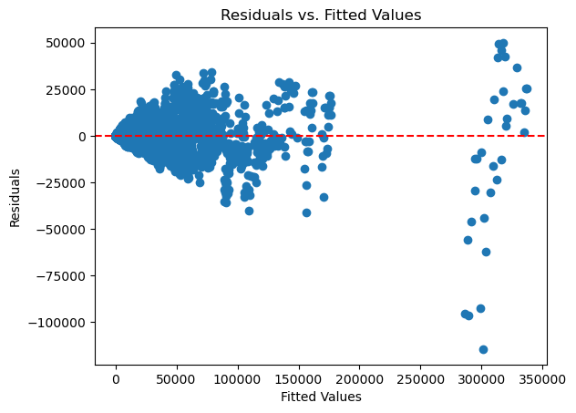

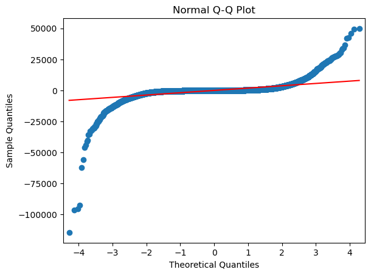

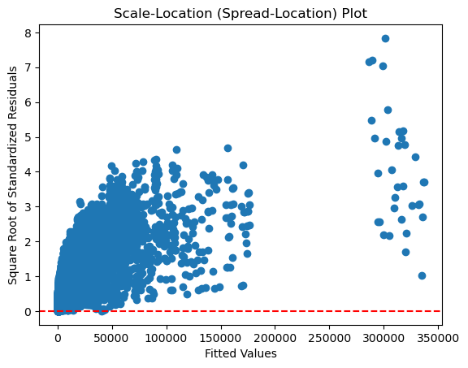

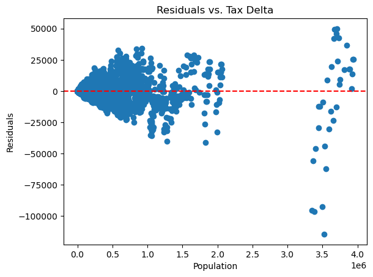

```python
# Validating for linearity assumptions

import statsmodels.api as sm
import matplotlib.pyplot as plt
import scipy.stats as stats
import numpy as np

# Assuming you have already fitted the linear regression model named 'model'

# Get fitted values and residuals
fitted_values = stats_model.fittedvalues
residuals = stats_model.resid

# 1. Residuals vs. Fitted Values Plot
plt.scatter(fitted_values, residuals)
plt.xlabel('Fitted Values')
plt.ylabel('Residuals')
plt.title('Residuals vs. Fitted Values')
plt.axhline(y=0, color='r', linestyle='--')  # Add a horizontal line at y=0
plt.show()

# 2. Normal Q-Q Plot
sm.qqplot(residuals, line='s')
plt.title('Normal Q-Q Plot')
plt.show()

# 3. Scale-Location (Spread-Location) Plot
sqrt_standardized_residuals = np.sqrt(np.abs(stats_model.get_influence().resid_studentized_internal))
plt.scatter(fitted_values, sqrt_standardized_residuals)
plt.xlabel('Fitted Values')
plt.ylabel('Square Root of Standardized Residuals')
plt.title('Scale-Location (Spread-Location) Plot')
plt.axhline(y=0, color='r', linestyle='--')  # Add a horizontal line at y=0
plt.show()

# 4. Residuals vs. Predictor Plot for ''
plt.scatter(df_diab_gender_pivot['Population'], residuals)
plt.xlabel('Population')
plt.ylabel('Residuals')
plt.title('Residuals vs. Tax Delta')
plt.axhline(y=0, color='r', linestyle='--')  # Add a horizontal line at y=0
plt.show()
```

##### Since the above model violates linearity assumptions, applying Box-Cox transoformation

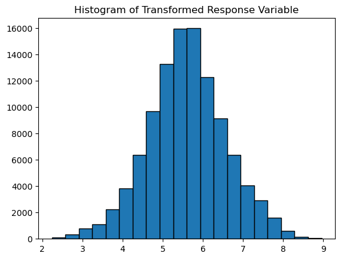

```
Lambda Value: -0.05965469325578518
                            OLS Regression Results
==============================================================================
Dep. Variable:                      y   R-squared:                       0.268
Model:                            OLS   Adj. R-squared:                  0.268
Method:                 Least Squares   F-statistic:                 1.303e+04
Date:                Sat, 25 Nov 2023   Prob (F-statistic):               0.00
Time:                        16:28:50   Log-Likelihood:            -1.3089e+05
No. Observations:              106631   AIC:                         2.618e+05
Df Residuals:                  106627   BIC:                         2.618e+05
Df Model:                           3
Covariance Type:            nonrobust
===============================================================================
                  coef    std err          t      P>|t|      [0.025      0.975]
-------------------------------------------------------------------------------
const           5.2394      0.005    971.103      0.000       5.229       5.250
tax_delta       4.8142      0.102     47.272      0.000       4.615       5.014
Population   3.998e-06   2.17e-08    184.310      0.000    3.96e-06    4.04e-06
Gender_Male     0.0501      0.005      9.913      0.000       0.040       0.060
==============================================================================
Omnibus:                    41465.859   Durbin-Watson:                   0.056
Prob(Omnibus):                  0.000   Jarque-Bera (JB):           651863.994
Skew:                          -1.451   Prob(JB):                         0.00
Kurtosis:                      14.760   Cond. No.                     4.96e+06
==============================================================================

Notes:
[1] Standard Errors assume that the covariance matrix of the errors is correctly specified.
[2] The condition number is large, 4.96e+06. This might indicate that there are
strong multicollinearity or other numerical problems.
```

```python
# Applying the Box-Cox transformation

# Apply Box-Cox Transformation to Response Variable
y_transformed, lambda_value = stats.boxcox(y + 1)  # Adding 1 to handle zero values

# Visualize the Transformed Response Variable
plt.hist(y_transformed, bins=20, edgecolor='black')
plt.title('Histogram of Transformed Response Variable')
plt.show()

# Check Lambda Value
print(f'Lambda Value: {lambda_value}')

# Fit a new model using the transformed response variable
stats_model_transformed = sm.OLS(y_transformed, X).fit()

# Print the summary of the transformed model
print(stats_model_transformed.summary())
```

##### Conclusion:

The model with response as number of diabetics and predictor variable tax delta and population:

- The lambda value is -0.059. Indicating the new model fit is on (((diabetics number^-0.059)-1)/-0.059). We will call this response as transformed y.
- One percent increase in scaled tax delta, keeping all other constant, increases the transformed by 4.81
- One unit increase in scaled population, keeping all other constant, increases the transformed y by 3.998*10^-6.
- All p-value are statistically significant
- Adjusted R-square is 0.268 indicating that the model can explain only 26.8% of variation in total number of diabetics patient
- Conditonal large number error still exists. Lets explore scaling to fix it.

```python
import statsmodels.api as sm
from sklearn.preprocessing import StandardScaler
import pandas as pd

df_diab_scaled = df_diab_gender_pivot.reset_index(drop=True)
df_diab_scaled

# Extract the independent variables (features) from your DataFrame
X = pd.get_dummies(df_diab_gender_pivot[['tax_delta','Population', 'Gender']], columns=['Gender'], drop_first=True)

# Extract the dependent variable from your DataFrame
y = df_diab_scaled['Gender Absolute']

# Initialize the StandardScaler
scaler = StandardScaler()

# Fit and transform the independent variables
X_scaled = scaler.fit_transform(X)

# Create a new DataFrame with the scaled features
X_scaled_df = pd.DataFrame(X_scaled, columns=X.columns)

# Add a constant term to the independent variables
X_scaled_df = sm.add_constant(X_scaled_df)

# Fit the linear regression model
model = sm.OLS(y, X_scaled_df).fit()

# Display the summary
print(model.summary())
```

```
                            OLS Regression Results
==============================================================================
Dep. Variable:        Gender Absolute   R-squared:                       0.966
Model:                            OLS   Adj. R-squared:                  0.966
Method:                 Least Squares   F-statistic:                 1.024e+06
Date:                Sat, 25 Nov 2023   Prob (F-statistic):               0.00
Time:                        16:28:51   Log-Likelihood:            -9.5472e+05
No. Observations:              106631   AIC:                         1.909e+06
Df Residuals:                  106627   BIC:                         1.909e+06
Df Model:                           3
Covariance Type:            nonrobust
===============================================================================
                  coef    std err          t      P>|t|      [0.025      0.975]
-------------------------------------------------------------------------------
const        3290.1045      5.732    574.037      0.000    3278.871    3301.338
tax_delta      11.9719      5.778      2.072      0.038       0.648      23.296
Population   1.005e+04      5.778   1738.865      0.000       1e+04    1.01e+04
Gender_Male    89.1887      5.732     15.560      0.000      77.955     100.423
==============================================================================
Omnibus:                   128516.159   Durbin-Watson:                   0.331
Prob(Omnibus):                  0.000   Jarque-Bera (JB):        790210641.903
Skew:                          -5.166   Prob(JB):                         0.00
Kurtosis:                     424.604   Cond. No.                         1.14
==============================================================================

Notes:
[1] Standard Errors assume that the covariance matrix of the errors is correctly specified.
```

##### Since the above model violates linearity assumptions, applying Box-Cox transformation to scaled parameters

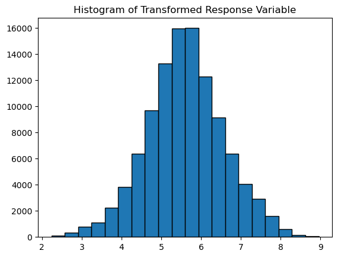

```
Lambda Value: -0.05965469325578518
                            OLS Regression Results
==============================================================================
Dep. Variable:                      y   R-squared:                       0.268
Model:                            OLS   Adj. R-squared:                  0.268
Method:                 Least Squares   F-statistic:                 1.303e+04
Date:                Sat, 25 Nov 2023   Prob (F-statistic):               0.00
Time:                        16:28:51   Log-Likelihood:            -1.3089e+05
No. Observations:              106631   AIC:                         2.618e+05
Df Residuals:                  106627   BIC:                         2.618e+05
Df Model:                           3
Covariance Type:            nonrobust
===============================================================================
                  coef    std err          t      P>|t|      [0.025      0.975]
-------------------------------------------------------------------------------
const           5.6029      0.003   2215.571      0.000       5.598       5.608
tax_delta       0.1205      0.003     47.272      0.000       0.116       0.126
Population      0.4699      0.003    184.310      0.000       0.465       0.475
Gender_Male     0.0251      0.003      9.913      0.000       0.020       0.030
==============================================================================
Omnibus:                    41465.859   Durbin-Watson:                   0.056
Prob(Omnibus):                  0.000   Jarque-Bera (JB):           651864.010
Skew:                          -1.451   Prob(JB):                         0.00
Kurtosis:                      14.760   Cond. No.                         1.14
==============================================================================

Notes:
[1] Standard Errors assume that the covariance matrix of the errors is correctly specified.
```

```python
# Applying the Box-Cox transformation

# Apply Box-Cox Transformation to Response Variable
y_transformed, lambda_value = stats.boxcox(y + 1)  # Adding 1 to handle zero values

# Visualize the Transformed Response Variable
plt.hist(y_transformed, bins=20, edgecolor='black')
plt.title('Histogram of Transformed Response Variable')
plt.show()

# Check Lambda Value
print(f'Lambda Value: {lambda_value}')

# Fit a new model using the transformed response variable
stats_model_transformed = sm.OLS(y_transformed, X_scaled_df).fit()

# Print the summary of the transformed model
print(stats_model_transformed.summary())
```

##### b. Total Population and Age - On Absolute Number

```python
import numpy as np
import pandas as pd
import statsmodels.api as sm
from sklearn.model_selection import train_test_split
from sklearn.linear_model import LinearRegression
from sklearn.metrics import mean_squared_error, r2_score

# Assuming 'Grocery Tax' and 'Restaurant Tax' are the features
X = pd.get_dummies(df_diab_age_pivot[['tax_delta', 'Population','Age']], columns=['Age'], drop_first=True)
y = df_diab_age_pivot['Age Diabetics Absolute']

# Add a constant term to the features matrix (required for statsmodels)
X = sm.add_constant(X)

# Create and fit the linear regression model using statsmodels
stats_model = sm.OLS(y, X).fit()

# Print the summary
print(stats_model.summary())
```

```
                              OLS Regression Results
==================================================================================
Dep. Variable:     Age Diabetics Absolute   R-squared:                       0.607
Model:                                OLS   Adj. R-squared:                  0.607
Method:                     Least Squares   F-statistic:                 6.119e+04
Date:                    Sat, 25 Nov 2023   Prob (F-statistic):               0.00
Time:                            16:28:51   Log-Likelihood:            -1.5646e+06
No. Observations:                  158645   AIC:                         3.129e+06
Df Residuals:                      158640   BIC:                         3.129e+06
Df Model:                               4
Covariance Type:                nonrobust
=================================================================================
                    coef    std err          t      P>|t|      [0.025      0.975]
---------------------------------------------------------------------------------
const         -1602.7114     27.744    -57.767      0.000   -1657.090   -1548.333
tax_delta      7823.2077    469.605     16.659      0.000    6902.793    8743.623
Population        0.0669      0.000    483.746      0.000       0.067       0.067
Age_45-64      2591.8481     28.652     90.458      0.000    2535.690    2648.006
Age_65-beyond  2927.3248     28.766    101.762      0.000    2870.943    2983.706
==============================================================================
Omnibus:                   193349.950   Durbin-Watson:                   2.450
Prob(Omnibus):                  0.000   Jarque-Bera (JB):       1006203770.958
Skew:                           5.335   Prob(JB):                         0.00
Kurtosis:                     393.007   Cond. No.                     3.58e+06
==============================================================================

Notes:
[1] Standard Errors assume that the covariance matrix of the errors is correctly specified.
[2] The condition number is large, 3.58e+06. This might indicate that there are
strong multicollinearity or other numerical problems.
```

##### Conclusion:

The model with response as number of diabetics and predictor variable tax delta and population:

- One percent increase in tax delta, keeping all other constant, increases the diabetics number by 7823.
- One unit increase in population, keeping all other constant, increases the diabetics number by 0.0669
- Adjusted R-square is 0.607 indicating that the model can explain only 60.7% of variation in total number of diabetics patient
- The conditional number is large and hence we need to check for multicollinearity
- This model has good R-square value but we need to validate the linearity assumptions and if any is violated, apply necessary trasformation

```python
# Checking for multicollinearity
from statsmodels.stats.outliers_influence import variance_inflation_factor

vif_data = pd.DataFrame()
vif_data["Variable"] = X.columns
vif_data["VIF"] = [variance_inflation_factor(X.values, i) for i in range(X.shape[1])]

# Check the VIF values
print(vif_data)
```

```
        Variable       VIF
0          const  5.659033
1      tax_delta  1.013754
2     Population  1.023592
3      Age_45-64  1.346559
4  Age_65-beyond  1.357166
```

##### Inference:

The VIF for predictor variables is small and hence multicollinearity does not exist. Scaling can fix the conditionally large number error if needed.

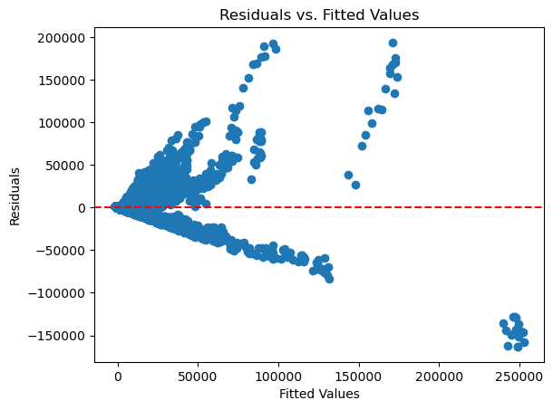

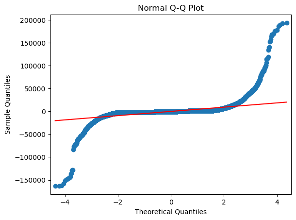

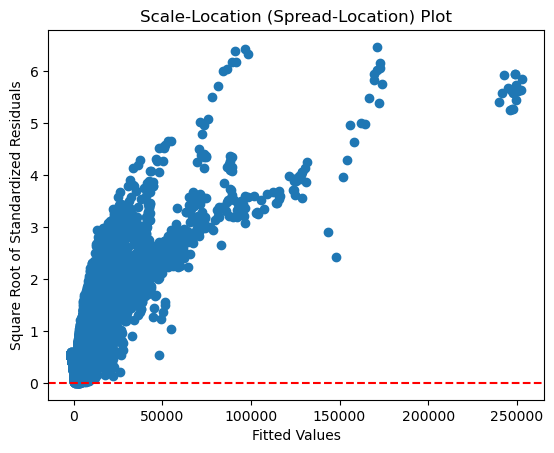

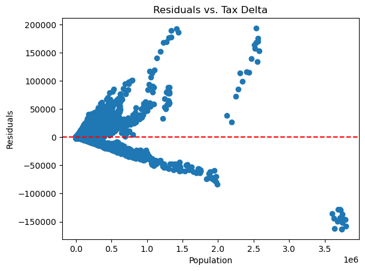

```python
# Validating for linearity assumptions

import statsmodels.api as sm
import matplotlib.pyplot as plt
import scipy.stats as stats
import numpy as np

# Assuming you have already fitted the linear regression model named 'model'

# Get fitted values and residuals
fitted_values = stats_model.fittedvalues
residuals = stats_model.resid

# 1. Residuals vs. Fitted Values Plot
plt.scatter(fitted_values, residuals)
plt.xlabel('Fitted Values')
plt.ylabel('Residuals')
plt.title('Residuals vs. Fitted Values')
plt.axhline(y=0, color='r', linestyle='--')  # Add a horizontal line at y=0
plt.show()

# 2. Normal Q-Q Plot
sm.qqplot(residuals, line='s')
plt.title('Normal Q-Q Plot')
plt.show()

# 3. Scale-Location (Spread-Location) Plot
sqrt_standardized_residuals = np.sqrt(np.abs(stats_model.get_influence().resid_studentized_internal))
plt.scatter(fitted_values, sqrt_standardized_residuals)
plt.xlabel('Fitted Values')
plt.ylabel('Square Root of Standardized Residuals')
plt.title('Scale-Location (Spread-Location) Plot')
plt.axhline(y=0, color='r', linestyle='--')  # Add a horizontal line at y=0
plt.show()

# 4. Residuals vs. Predictor Plot for ''
plt.scatter(df_diab_age_pivot['Population'], residuals)
plt.xlabel('Population')
plt.ylabel('Residuals')
plt.title('Residuals vs. Tax Delta')
plt.axhline(y=0, color='r', linestyle='--')  # Add a horizontal line at y=0
plt.show()
```

##### Since the above model violates linearity assumptions, applying Box-Cox transoformation

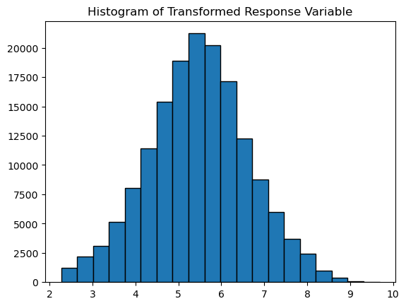

```
Lambda Value: -0.04587186613756453
                            OLS Regression Results
==============================================================================
Dep. Variable:                      y   R-squared:                       0.346
Model:                            OLS   Adj. R-squared:                  0.346
Method:                 Least Squares   F-statistic:                 2.094e+04
Date:                Sat, 25 Nov 2023   Prob (F-statistic):               0.00
Time:                        16:28:57   Log-Likelihood:            -2.1583e+05
No. Observations:              158645   AIC:                         4.317e+05
Df Residuals:                  158640   BIC:                         4.317e+05
Df Model:                           4
Covariance Type:            nonrobust
=================================================================================
                    coef    std err          t      P>|t|      [0.025      0.975]
---------------------------------------------------------------------------------
const             4.4598      0.006    791.678      0.000       4.449       4.471
tax_delta         5.4273      0.095     56.919      0.000       5.240       5.614
Population     6.075e-06   2.81e-08    216.481      0.000    6.02e-06    6.13e-06
Age_45-64         0.9407      0.006    161.697      0.000       0.929       0.952
Age_65-beyond     0.9885      0.006    169.236      0.000       0.977       1.000
==============================================================================
Omnibus:                    69246.821   Durbin-Watson:                   0.191
Prob(Omnibus):                  0.000   Jarque-Bera (JB):          2242696.824
Skew:                          -1.474   Prob(JB):                         0.00
Kurtosis:                      21.182   Cond. No.                     3.58e+06
==============================================================================

Notes:
[1] Standard Errors assume that the covariance matrix of the errors is correctly specified.
[2] The condition number is large, 3.58e+06. This might indicate that there are
strong multicollinearity or other numerical problems.
```

```python
# Applying the Box-Cox transformation

# Apply Box-Cox Transformation to Response Variable
y_transformed, lambda_value = stats.boxcox(y + 1)  # Adding 1 to handle zero values

# Visualize the Transformed Response Variable
plt.hist(y_transformed, bins=20, edgecolor='black')
plt.title('Histogram of Transformed Response Variable')
plt.show()

# Check Lambda Value
print(f'Lambda Value: {lambda_value}')

# Fit a new model using the transformed response variable
stats_model_transformed = sm.OLS(y_transformed, X).fit()

# Print the summary of the transformed model
print(stats_model_transformed.summary())
```

##### Conclusion:

The model with response as number of diabetics and predictor variable tax delta and population:

- The lambda value is -0.045. Indicating the new model fit is on (((diabetics number^-0.045)-1)/-0.045). We will call this response as transformed y.
- One percent increase in scaled tax delta, keeping all other constant, increases the transformed by 5.43.
- One unit increase in scaled population, keeping all other constant, increases the transformed y by 6x10^-6.
- All p-value are statistically significant
- Adjusted R-square is 0.346 indicating that the model can explain only 34.6% of variation in total number of diabetics patient

```python
import statsmodels.api as sm
from sklearn.preprocessing import StandardScaler
import pandas as pd

df_diab_scaled = df_diab_age_pivot.reset_index(drop=True)
df_diab_scaled

# Extract the independent variables (features) from your DataFrame
X = pd.get_dummies(df_diab_scaled[['tax_delta','Population', 'Age']], columns=['Age'], drop_first=True)
# Extract the dependent variable from your DataFrame
y = df_diab_scaled['Age Diabetics Absolute']

# Initialize the StandardScaler
scaler = StandardScaler()

# Fit and transform the independent variables
X_scaled = scaler.fit_transform(X)

# Create a new DataFrame with the scaled features
X_scaled_df = pd.DataFrame(X_scaled, columns=X.columns)

# Add a constant term to the independent variables
X_scaled_df = sm.add_constant(X_scaled_df)

# Fit the linear regression model
model = sm.OLS(y, X_scaled_df).fit()

# Display the summary
print(model.summary())
```

```
                              OLS Regression Results
==================================================================================
Dep. Variable:     Age Diabetics Absolute   R-squared:                       0.607
Model:                                OLS   Adj. R-squared:                  0.607
Method:                     Least Squares   F-statistic:                 6.119e+04
Date:                    Sat, 25 Nov 2023   Prob (F-statistic):               0.00
Time:                            16:28:57   Log-Likelihood:            -1.5646e+06
No. Observations:                  158645   AIC:                         3.129e+06
Df Residuals:                      158640   BIC:                         3.129e+06
Df Model:                               4
Covariance Type:                nonrobust
=================================================================================
                    coef    std err          t      P>|t|      [0.025      0.975]
---------------------------------------------------------------------------------
const          2211.3428     11.663    189.606      0.000    2188.484    2234.202
tax_delta       195.6245     11.743     16.659      0.000     172.609     218.640
Population     5708.0191     11.800    483.746      0.000    5684.892    5731.146
Age_45-64      1224.2379     13.534     90.458      0.000    1197.712    1250.764
Age_65-beyond  1382.6270     13.587    101.762      0.000    1355.997    1409.257
==============================================================================
Omnibus:                   193349.950   Durbin-Watson:                   2.450
Prob(Omnibus):                  0.000   Jarque-Bera (JB):       1006203770.965
Skew:                           5.335   Prob(JB):                         0.00
Kurtosis:                     393.007   Cond. No.                         1.76
==============================================================================

Notes:
[1] Standard Errors assume that the covariance matrix of the errors is correctly specified.
```

##### Since the above model violates linearity assumptions, applying Box-Cox transformation to scaled parameters

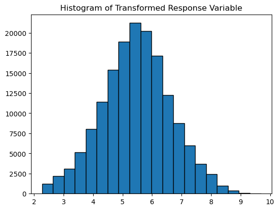

```
Lambda Value: -0.04587186613756453
                            OLS Regression Results
==============================================================================
Dep. Variable:                      y   R-squared:                       0.346
Model:                            OLS   Adj. R-squared:                  0.346
Method:                 Least Squares   F-statistic:                 2.094e+04
Date:                Sat, 25 Nov 2023   Prob (F-statistic):               0.00
Time:                        16:28:58   Log-Likelihood:            -2.1583e+05
No. Observations:              158645   AIC:                         4.317e+05
Df Residuals:                  158640   BIC:                         4.317e+05
Df Model:                           4
Covariance Type:            nonrobust
=================================================================================
                    coef    std err          t      P>|t|      [0.025      0.975]
---------------------------------------------------------------------------------
const             5.4743      0.002   2311.714      0.000       5.470       5.479
tax_delta         0.1357      0.002     56.919      0.000       0.131       0.140
Population        0.5187      0.002    216.481      0.000       0.514       0.523
Age_45-64         0.4443      0.003    161.697      0.000       0.439       0.450
Age_65-beyond     0.4669      0.003    169.236      0.000       0.461       0.472
==============================================================================
Omnibus:                    69246.822   Durbin-Watson:                   0.191
Prob(Omnibus):                  0.000   Jarque-Bera (JB):          2242696.931
Skew:                          -1.474   Prob(JB):                         0.00
Kurtosis:                      21.182   Cond. No.                         1.76
==============================================================================

Notes:
[1] Standard Errors assume that the covariance matrix of the errors is correctly specified.
```

```python
# Applying the Box-Cox transformation

# Apply Box-Cox Transformation to Response Variable
y_transformed, lambda_value = stats.boxcox(y + 1)  # Adding 1 to handle zero values

# Visualize the Transformed Response Variable
plt.hist(y_transformed, bins=20, edgecolor='black')
plt.title('Histogram of Transformed Response Variable')
plt.show()

# Check Lambda Value
print(f'Lambda Value: {lambda_value}')

# Fit a new model using the transformed response variable
stats_model_transformed = sm.OLS(y_transformed, X_scaled_df).fit()

# Print the summary of the transformed model
print(stats_model_transformed.summary())
```

##### Conclusion:

The model with response as number of diabetics and predictor variable tax and population:

- The lambda value is -0.046. Indicating the new model fit is on (((diabetics number^-0.046)-1)/-0.046). We will call this response as transformed y.
- One percent increase in scaled tax delta, keeping all other constant, increases the transformed by 0.1357.
- One unit increase in scaled population, keeping all other constant, increases the transformed y by 0.5187 .
- All p-value are statistically significant
- Adjusted R-square is 0.346 indicating that the model can explain only 34.6% of variation in total number of diabetics patient
- Conditonal large number error has been fixed

### Final Conclusion:

- The best model for explaining Diabetics Number variation with Tax, after accounting for necessary controls and corrections of assumptions, is the model with response, (((diabetics number^-0.046)-1)/-0.046); and scaled predictor tax delta, population and age control
- This model explains for 34.6% variability in diabetics number
- We shall continue to research the impact on diabetics percentage and also a study on tax delta.